# av-job-a-thon-november-2022-eda

### Introduction

#### Build a machine learning/deep learning approach to forecast the total energy demand on an hourly basis for the next 3 years based on past trends.

### Import the necessary packages.

```python
!pip install -q klib
```

```
WARNING: Running pip as the 'root' user can result in broken permissions and conflicting behaviour with the system package manager. It is recommended to use a virtual environment instead: https://pip.pypa.io/warnings/venv
```

```python
import numpy as np # linear algebra
import pandas as pd # data processing, CSV file I/O (e.g. pd.read_csv)
import seaborn as sns # visualization
from matplotlib import pyplot as plt # visualization
%matplotlib inline
import warnings
warnings.filterwarnings("ignore")
import re
import klib
```

### Import train and test dataset

```python
train=pd.read_csv("../input/forecast-green-energy/train_IxoE5JN.csv")
test=pd.read_csv("../input/forecast-green-energy/test_WudNWDM.csv")
```

### Structure of the train and test dataset.

```python
train.info()
```

```
<class 'pandas.core.frame.DataFrame'>
RangeIndex: 94992 entries, 0 to 94991
Data columns (total 3 columns):
 #   Column    Non-Null Count  Dtype
---  ------    --------------  -----
 0   row_id    94992 non-null  int64
 1   datetime  94992 non-null  object
 2   energy    93092 non-null  float64
dtypes: float64(1), int64(1), object(1)
memory usage: 2.2+ MB
```

#### The above information shows that there are 94992 data entries and 3 columns.

```python
test.info()
```

```
<class 'pandas.core.frame.DataFrame'>
RangeIndex: 26304 entries, 0 to 26303
Data columns (total 2 columns):
 #   Column    Non-Null Count  Dtype
---  ------    --------------  -----
 0   row_id    26304 non-null  int64
 1   datetime  26304 non-null  object
dtypes: int64(1), object(1)
memory usage: 411.1+ KB
```

#### The above information shows that there are 26304 data entries and 2 columns.

#### Let's see is there any missing values in train and test dataset by column wise.

```python
train.isnull().sum()
```

```
row_id         0
datetime       0
energy      1900
dtype: int64
```

#### The above information shows that there are missing values in the target column.

```python
test.isnull().sum()
```

```
row_id      0
datetime    0
dtype: int64
```

#### Let's see the glimpse of train dataset

```python
train.head()
```

|  | row_id | datetime | energy |
| --- | --- | --- | --- |
| 0 | 1 | 2008-03-01 00:00:00 | 1259.985563 |
| 1 | 2 | 2008-03-01 01:00:00 | 1095.541500 |
| 2 | 3 | 2008-03-01 02:00:00 | 1056.247500 |
| 3 | 4 | 2008-03-01 03:00:00 | 1034.742000 |
| 4 | 5 | 2008-03-01 04:00:00 | 1026.334500 |

### Let's create a function for box plot.

```python
def box_plot(df,col,rot=None):
  _=plt.figure(figsize=(8,6))
  _=sns.boxplot(y=df[col])
  _=plt.title(col.capitalize()+" Distribution",fontsize=25)
  _=plt.ylabel(col,fontsize=20,rotation=rot)
  _=plt.yticks(fontsize=14)
```

### Let's see the demand column distribution.

```
Large dataset detected, using 10000 random samples for the plots. Summary statistics are still based on the entire dataset.
```

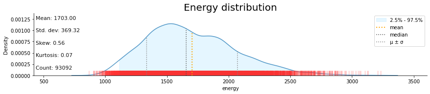

```python
klib.dist_plot(train['energy']);
plt.title("Energy distribution".capitalize(),fontsize=20);
```

```python
train['energy'].describe()
```

```
count    93092.000000
mean      1702.995014
std        369.322103
min        866.388600
25%       1431.541100
50%       1654.465800
75%       1935.993450
max       3374.399600
Name: energy, dtype: float64
```

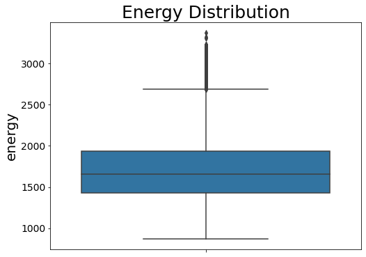

```python
box_plot(train,'energy',rot=90)
```

#### The demand ranges from 866.388 to 3374.3996

#### The average demand value is 1702.995.

#### The boxplot explains that there are outliers above the third quartile.

#### Let's do some feature engineering on date column.

```python
def pre_process(df):
    df['date_time']=pd.to_datetime(df["datetime"]) #convert to date-time format
    df['day']=df['date_time'].dt.day #extract day from the date
    df['day_label']=df['date_time'].dt.day_name() #extract the day name from the date
    df['day_number']=df['date_time'].dt.dayofweek #extract the day number from the date
    df['month_number']=df['date_time'].dt.month #extract month number from the date
    df['month_label']=df['date_time'].dt.strftime('%b') #extract the month name from the date
    df['year_quarter']=df['date_time'].dt.quarter #extract the quarter of the year
    df['week_of_year']=df['date_time'].dt.week #extract week of the year from date
    df['year']= df['date_time'].dt.year #extract year
    df['dayofmonth'] = df['date_time'].dt.daysinmonth #extract the day of the month
    df['dayofyear'] = df['date_time'].dt.day_of_year #extract day of the year
    df['weekday']=df['date_time'].dt.day_name().isin(['Monday', 'Tuesday', 'Wednesday', 'Thursday', 'Friday']).astype('int') #create weekday column
    df['weekend']=df['date_time'].dt.day_name().isin(['Saturday', 'Sunday']).astype('int') #create weekend column
    df['month_start']=df['date_time'].dt.is_month_start.astype('int') #create month start
    df['month_end']=df['date_time'].dt.is_month_end.astype('int') #create month end
    df['quarter_start']=df['date_time'].dt.is_quarter_start.astype('int') #create quarter start
    df['quarter_end']=df['date_time'].dt.is_quarter_end.astype('int') #create quarter end
    df['year_start']=df['date_time'].dt.is_year_start.astype('int') #create year start
    df['year_end']=df['date_time'].dt.is_year_end.astype('int') #create year end
    df['hour']=df['date_time'].dt.hour

  #function to convert month to seasons
    def month2seasons(x):
        season=""
        if x in [1, 2]:
            season = 'winter'
        elif x in [3, 4, 5]:
            season = 'summer'
        elif x in [6,7,8,9]:
            season = 'monsoon'
        elif x in [10,11,12]:
            season = 'post-monsoon'
        return season


    df['seasons']=df['month_number'].apply(month2seasons)

    def hours2timing(x):
        if x in range(20,23):
            timing = 'Night'
        elif x in range(5,12):
            timing = 'Morning'
        elif x in range(12, 16):
            timing = 'Afternoon'
        elif x in range(16, 20):
            timing = 'Evening'
        elif x in [23,0,1,2,3,4]:
            timing = 'Midnight'
        else:
            timing = 'X'
        return timing



    df['timings']=df['hour'].apply(hours2timing)

    return df
```

```python
train=pre_process(train)
```

### Let's see how the demand for energy changes over the period.

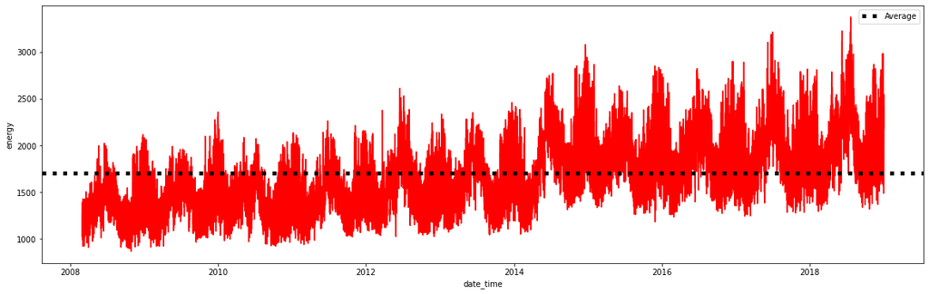

```python
plt.figure(figsize=(20,6))
yr=sns.lineplot(x=train['date_time'],y=train['energy'],color="Red")
yr.axhline(train.groupby('date_time')['energy'].agg({'mean'}).mean()[0],
          ls=":",color="Black",lw=5,label='Average');
plt.legend();
```

### The above plot explains that the energy demand increased after the year 2014.

### Let's see how the demand for energy changes over 12 months.

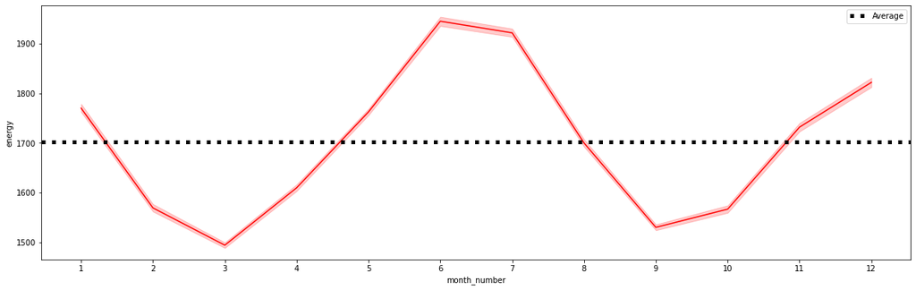

```python
plt.figure(figsize=(20,6))
month=sns.lineplot(x=train['month_number'],y=train['energy'],color="Red")
month.axhline(train.groupby('month_number')['energy'].agg({'mean'}).mean()[0],
          ls=":",color="Black",lw=5,label='Average');
plt.legend();
plt.xticks(range(1,13));
```

#### The demand for energy is low in the month of February, March, April, August, September, and October(lower than the 12-month average).

### Let's see how the demand for energy changes over the 52 weeks of the year.

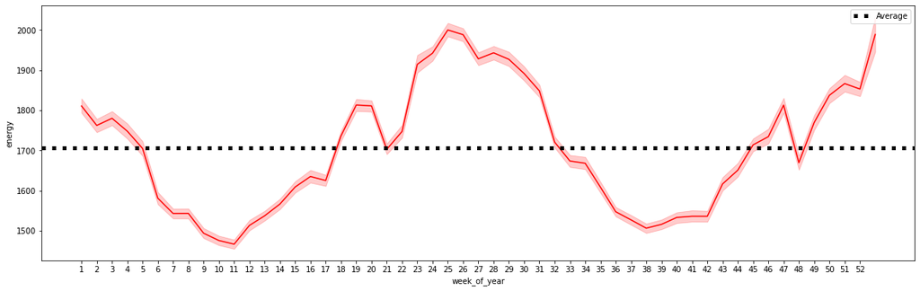

```python
plt.figure(figsize=(20,6))
week=sns.lineplot(x=train['week_of_year'],y=train['energy'],color="Red")
week.axhline(train.groupby('week_of_year')['energy'].agg({'mean'}).mean()[0],
          ls=":",color="Black",lw=5,label='Average');
plt.legend();
plt.xticks(range(1,53));
```

#### The demand for energy is low in weeks 5 to 17, 33 to 44, and 48 (lower than the 52-week average).

### Let's see how the demand for energy changes over the 24 hours of the day.

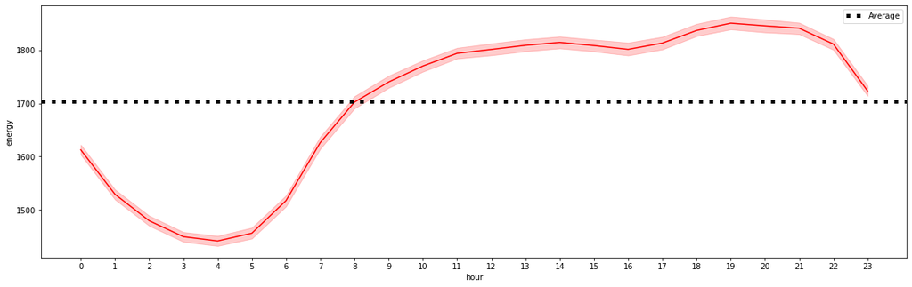

```python
plt.figure(figsize=(20,6))
hour=sns.lineplot(x=train['hour'],y=train['energy'],color="Red",
                )
hour.axhline(train.groupby('hour')['energy'].agg({'mean'}).mean()[0],
          ls=":",color="Black",lw=5,label='Average');
plt.legend();
plt.xticks(range(0,24));
```

### Let's see how the demand for energy changes over time with different climate seasons.

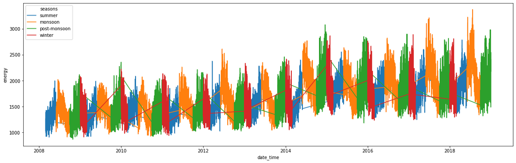

```python
plt.figure(figsize=(20,6))
_=sns.lineplot(x=train['date_time'],y=train['energy'],hue=train['seasons'])
```

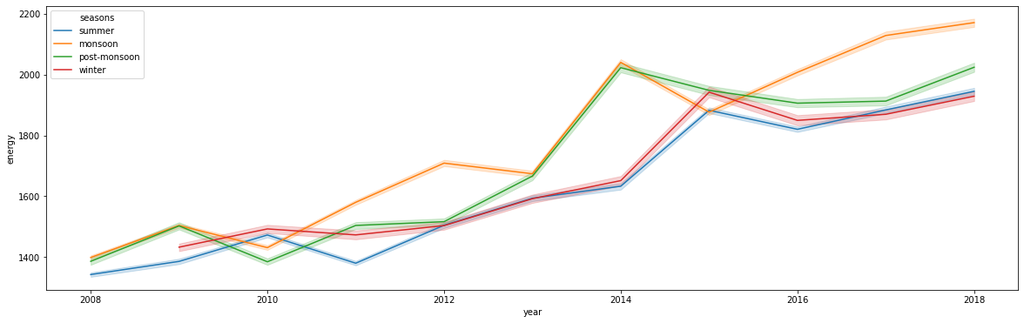

```python
plt.figure(figsize=(20,6))
_=sns.lineplot(x=train['year'],y=train['energy'],hue=train['seasons'])
```

#### After 2014, there is a high demand for energy in all seasons.

#### After the year 2014, in the monsoon and post-monsoon seasons, the energy demand is very high.

### Let's see how the demand for energy changes over the years with different timings of the day.

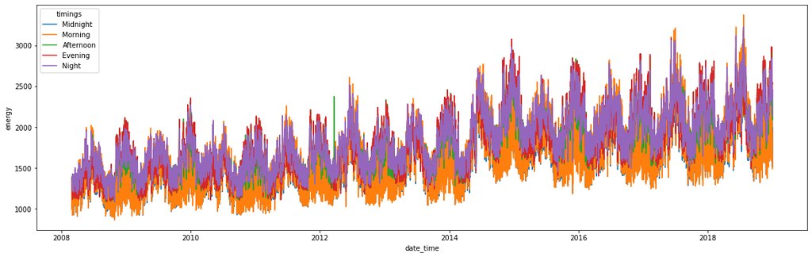

```python
plt.figure(figsize=(20,6))
_=sns.lineplot(x=train['date_time'],y=train['energy'],hue=train['timings'])
```

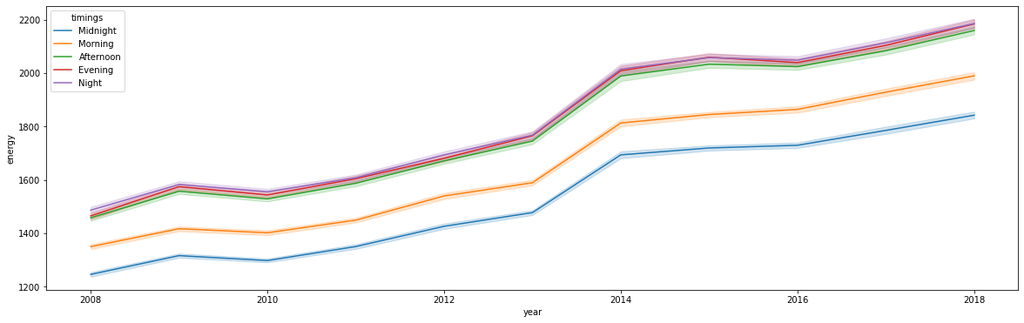

```python
plt.figure(figsize=(20,6))
_=sns.lineplot(x=train['year'],y=train['energy'],hue=train['timings'])
```

### Let's see how the demand for energy changes over the years with different days of the week.

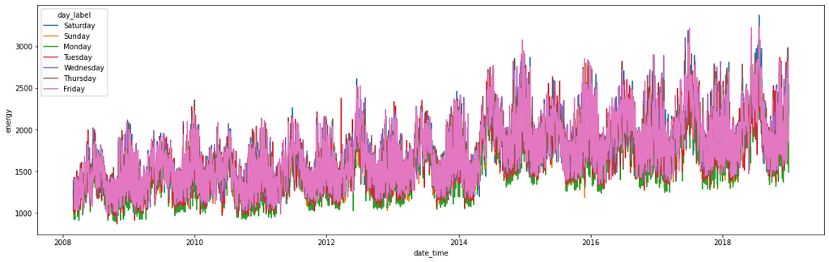

```python
plt.figure(figsize=(20,6))
_=sns.lineplot(x=train['date_time'],y=train['energy'],hue=train['day_label'])
```

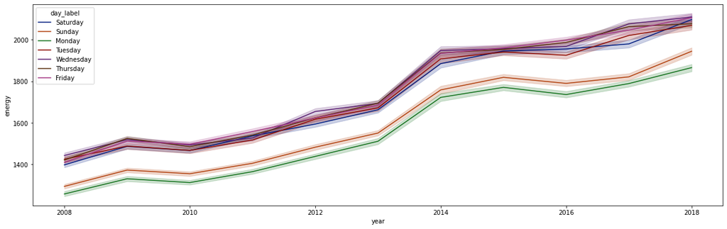

```python
plt.figure(figsize=(20,6))
_=sns.lineplot(x=train['year'],y=train['energy'],hue=train['day_label'],palette='dark')
```

#### The above plot explains that except for Sunday and Monday the demand for energy is high for other days of the week over the years.

### Let's use a grid plot and see how the energy demand changed over the 52 weeks of the year based on different timings of the day.

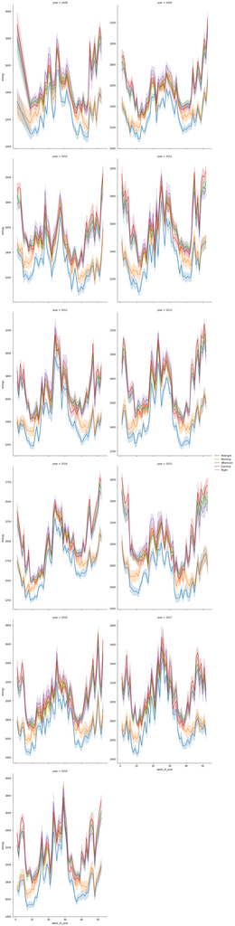

```python
g = sns.FacetGrid(train, col="year",sharey=False,col_wrap=2,height=9,aspect=.7)
g.map_dataframe(sns.lineplot, x="week_of_year", y="energy",hue=train['timings'])
g.add_legend()
```

#### The above plot explains that each year the energy demand shows various patterns at different timing of the day.

### Let's use acf and pacf and see how values are correlated with the previous values.

```python
import statsmodels.api as sm
```

### ACF function

```python
def acf_plot(df,date,valcol,lag):
    plt.rc("figure", figsize=(16,8))
    x=train[[date,valcol]]
    x=x.dropna(axis=0)
    x.set_index(date,inplace=True)
    lag_acf = sm.graphics.tsa.plot_acf(x[valcol], lags=lag)
    plt.title(valcol)
    plt.xticks(range(52))
```

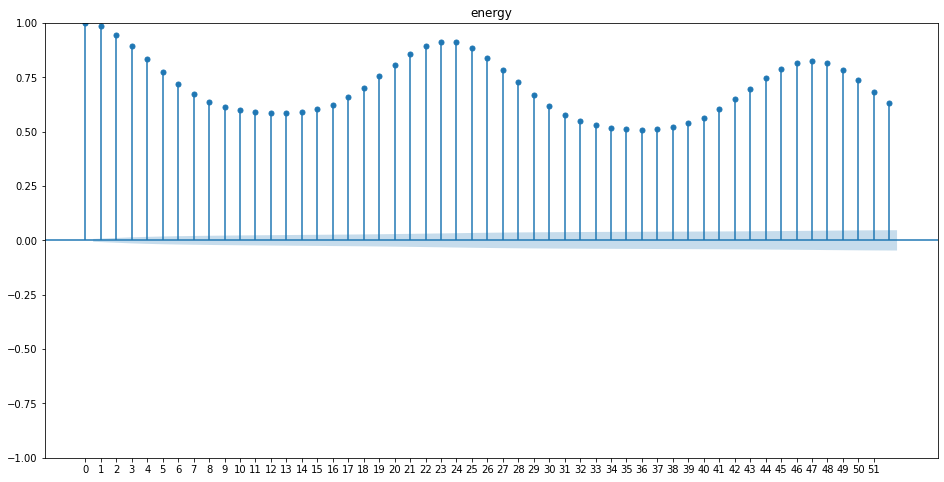

```python
acf_plot(train,'date_time','energy',lag=52)
```

### PACF function

```python
def pacf_plot(df,date,valcol,lag):
    plt.rc("figure", figsize=(16,8))
    x=train[[date,valcol]]
    x=x.dropna(axis=0)
    x.set_index(date,inplace=True)
    lag_pacf = sm.graphics.tsa.plot_pacf(x[valcol], lags=lag)
    plt.title(valcol)
    plt.xticks(range(52))
```

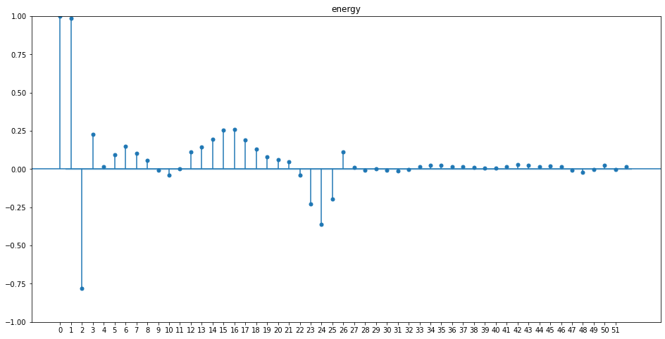

```python
pacf_plot(train,'date_time','energy',lag=52)
```

```python
from statsmodels.tsa.stattools import adfuller
```

### ADF test function

```python
def adf_test(df,date,valcol):
    x=df[[date,valcol]]
    x=x.dropna(axis=0)
    x.set_index(date,inplace=True)
    print("Observations of Dickey-fuller test")
    dftest = adfuller(x[valcol],autolag='AIC')
    dfoutput=pd.Series(dftest[0:4],index=['Test Statistic','p-value','#lags used','number of observations used'])
    for key,value in dftest[4].items():
        dfoutput['critical value (%s)'%key]= value
    print(dfoutput)
```

```python
adf_test(train,'date_time','energy')
```

```
Observations of Dickey-fuller test
Test Statistic                -9.527076e+00
p-value                        2.958121e-16
#lags used                     6.700000e+01
number of observations used    9.302400e+04
critical value (1%)           -3.430420e+00
critical value (5%)           -2.861571e+00
critical value (10%)          -2.566787e+00
dtype: float64
```

#### The above test explains that the p-value is <0.05 so we reject the null hypothesis(non-stationary) and conclude data is stationary.